# Lab 1

Rachel Castellino

1/17/2020

```r
library(tidyverse)
hiphop <- read_csv("https://www.dropbox.com/s/5d8fwxrj3jtua1z/hiphop.csv?dl=1")
```

# QUESTION 1

Provide a brief overview (2-4 sentences) of the dataset. (It is always good practice to start an analysis by getting a feel for the data and providing a quick summary for readers.) You do not need to show any source code for this question, although you probably want to use code to get information.

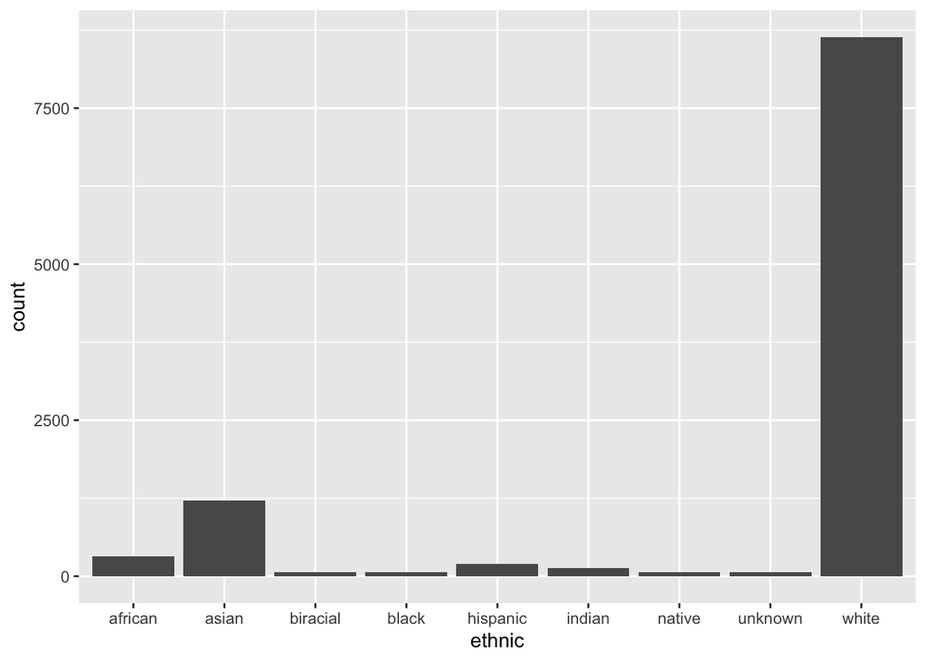

```r
ggplot(data = hiphop) +
  geom_bar(mapping = aes(x = ethnic))
```

Summarizing the data by ethnicity, this study is overwhelmingly white which does not seem like an even distribution of races to conduct a proper study. The smallest groups of ethnicities are biracial, black, native and unknown. Asian is the second highest ethnic group.

# QUESTION 2

Clean the dataset in whichever ways you see fit.

```r
hiphop_clean <- hiphop %>%
  mutate(
  sex = as.factor(as.character(sex)),
  word = as.factor(as.character(word)),
  subj = as.factor(as.character(subj)),
  ethnic = as.factor(as.character(ethnic)))
```

# QUESTION 3

How many unique AAVE words were studied in this dataset?

```r
hiphop %>%
  group_by(word) %>%
  summarize(num = n()) %>%
  nrow()
```

```
## [1] 64
```

# QUESTION 4

Make a new variable that recategorizes ethnic into only two groups, “white” and “non-white”, to simplify your data.

Helpful functions: mutate(), case_when()

```r
hiphop_clean <- hiphop_clean %>%
  mutate(clean_ethnic = case_when(
      ethnic == 'white' ~ 'white',
      ethnic != 'white' ~ 'non white'
    )
  )

hiphop_clean <- hiphop_clean %>%
  mutate(
  clean_ethnic = as.factor(as.character(clean_ethnic)))
```

# QUESTION 5

What are the demographics of the people in this study? Investigate the variables sex, age, and ethnic and summarize your findings in 1-3 complete sentences.

Helpful functions: select(), unique() or distinct(, .keep_all = TRUE), count(), summary()

```r
hiphop %>%
  group_by(sex) %>%
  summarize(sex_n = n()) %>%
  nrow()
```

```
## [1] 2
```

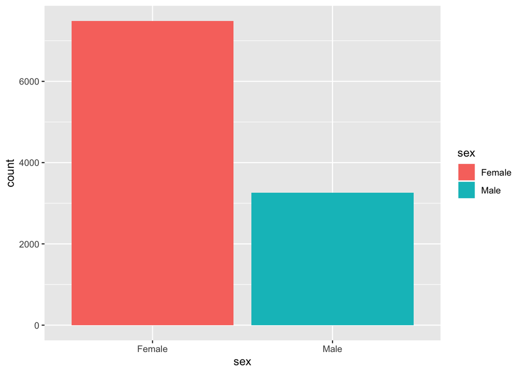

```r
ggplot (data = hiphop_clean) +
  geom_bar(mapping = aes(x = sex, fill = sex))
```

```r
hiphop %>%
  group_by(age) %>%
  summarize(age_n = n()) %>%
  nrow()
```

```
## [1] 21
```

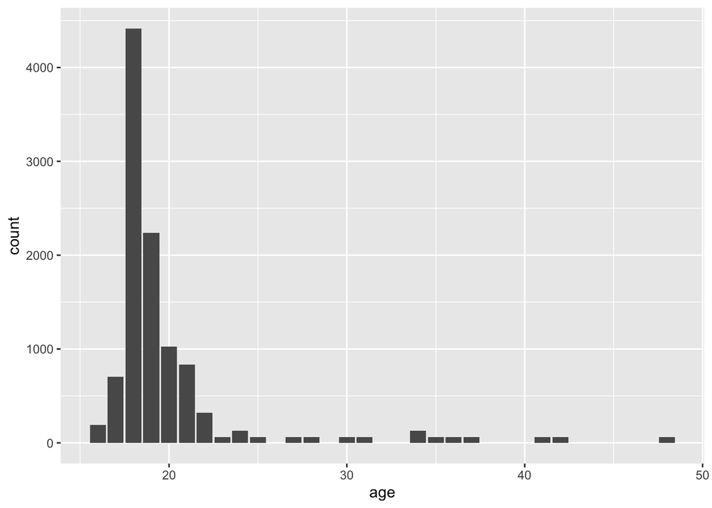

```r
ggplot (data = hiphop_clean) +
  geom_bar(mapping = aes(x = age, fill = age))
```

```r
hiphop %>%
  group_by(ethnic) %>%
  summarize(ethnic_n = n()) %>%
  nrow()
```

```
## [1] 9
```

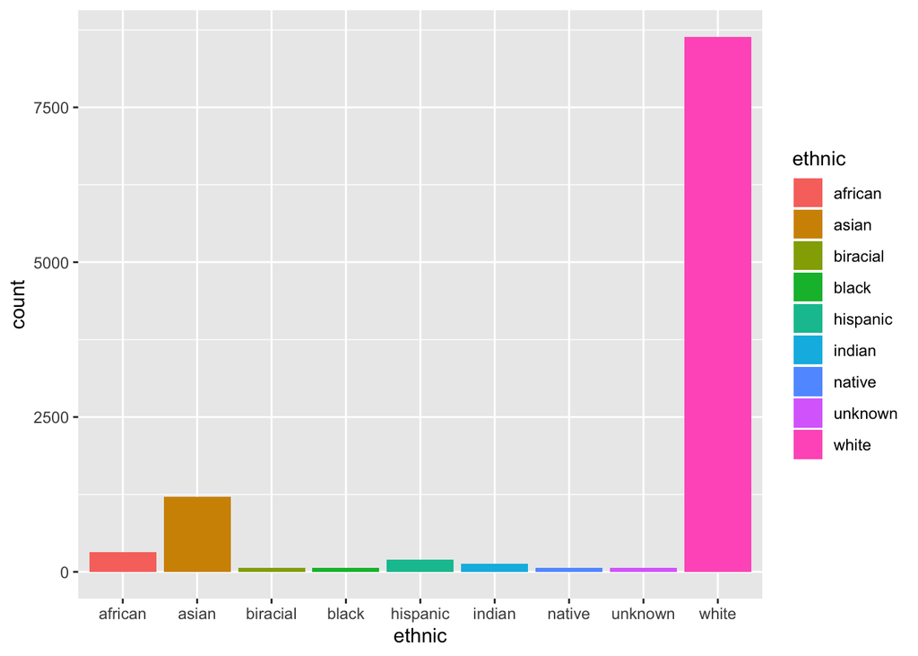

```r
ggplot (data = hiphop_clean) +
  geom_bar(mapping = aes(x = ethnic, fill = ethnic))
```

There are 2 sexes in the study, male and female. There are 21 ages in the study and 9 ethnicties shown by the graphs above.

# QUESTION 6

Make at least two plots to display the demographic information of the subjects in this study. You do not need to discuss these plots, but make sure they are appropriate to the data types and have informative titles and axis labels.

Functions: ggplot(), geom_histogram(), geom_boxplot(), geom_bar(), ggtitle(), xlab(), ylab()

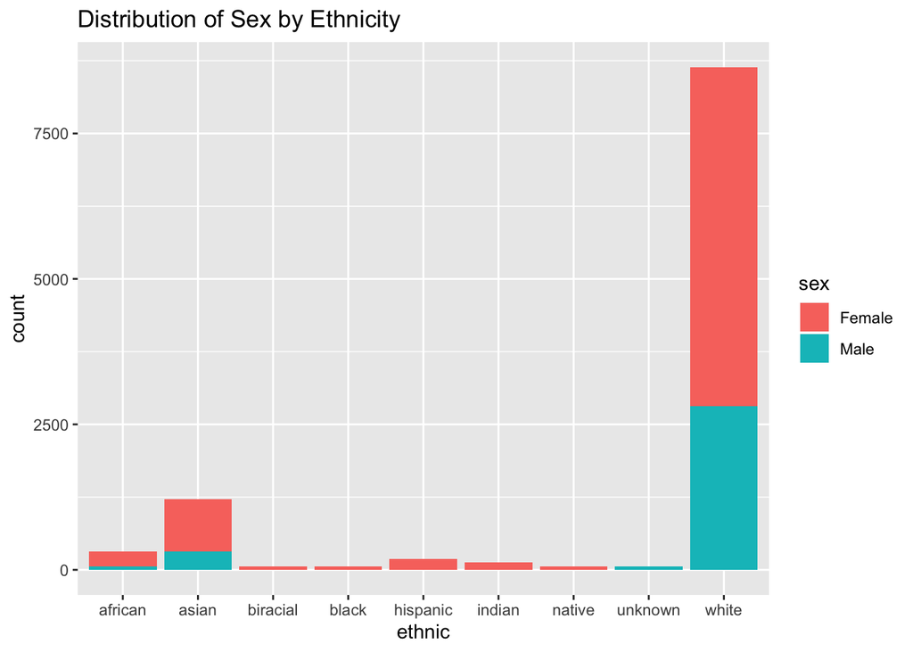

```r
ggplot(data = hiphop_clean) +
  geom_bar(mapping = aes(x = ethnic, fill = sex)) +
  ggtitle('Distribution of Sex by Ethnicity')
```

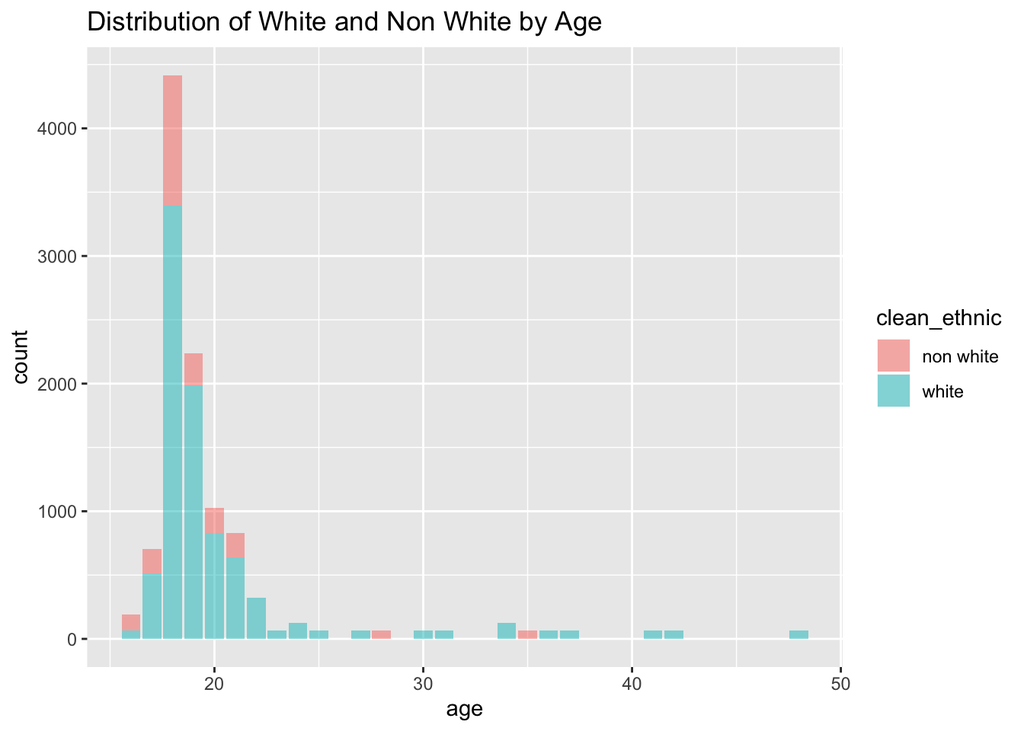

```r
ggplot(data = hiphop_clean) +
  geom_bar(mapping = aes(x = age, fill = clean_ethnic), alpha = 0.5) +
  ggtitle('Distribution of White and Non White by Age')
```

# QUESTION 1

For each demographic group listed below, determine which word(s) in this study was the most and least familiar on average.

People below the age of 20 Non-white women White men above the age of 30 Helpful functions: filter(), arrange(), desc(), top_n()

```r
hiphop_clean %>%
  group_by(word) %>%
  filter(age < 20) %>%
  summarize(data1 = mean(familiarity, na.rm = TRUE)) %>%
  arrange(desc(data1)) %>%
  filter(data1 > 4 | data1 < 2) %>%
  arrange(data1)
```

```
## # A tibble: 46 x 2
##    word              data1
##    <fct>             <dbl>
##  1 catch the vapors   1.03
##  2 domino             1.03
##  3 The Nation         1.04
##  4 face gator         1.10
##  5 rollie             1.10
##  6 break someone out  1.11
##  7 dollar cab         1.11
##  8 saditty            1.11
##  9 grip grain         1.12
## 10 humming            1.12
## # … with 36 more rows
```

```r
hiphop_clean %>%
  group_by(word) %>%
  filter(clean_ethnic == 'non white') %>%
  filter(sex == 'Female') %>%
  summarize(data2 = mean(familiarity, na.rm = TRUE)) %>%
  arrange(desc(data2)) %>%
  filter(data2 > 4 | data2 < 2) %>%
  arrange(data2)
```

```
## # A tibble: 45 x 2
##    word              data2
##    <fct>             <dbl>
##  1 break someone out  1
##  2 dukey rope         1
##  3 plex               1
##  4 rollie             1
##  5 The Nation         1.04
##  6 dollar cab         1.08
##  7 domino             1.08
##  8 catch the vapors   1.12
##  9 crossroads         1.15
## 10 face gator         1.15
## # … with 35 more rows
```

```r
hiphop_clean %>%
  group_by(word) %>%
  filter(age > 30) %>%
  filter(clean_ethnic == 'white') %>%
  filter(sex == 'Male') %>%
  summarize(data3 = mean(familiarity, na.rm = TRUE)) %>%
  arrange(desc(data3)) %>%
  filter(data3 > 4 | data3 < 2) %>%
  arrange(data3)
```

```
## # A tibble: 42 x 2
##    word              data3
##    <fct>             <dbl>
##  1 ay yo trip            1
##  2 beezy                 1
##  3 break someone out     1
##  4 catch the vapors      1
##  5 crossroads            1
##  6 crump                 1
##  7 dap                   1
##  8 dollar cab            1
##  9 domino                1
## 10 duckets               1
## # … with 32 more rows
```

### QUESTION 2

For each demographic comparison below, determine which music genre most differentiates the groups. That is, which genre had much higher average (mean or median) score in one group than the other.

Male versus Female White versus Non-White Age below 21 versus age 21+ Helpful functions: group_by(), summarize_at(), distinct()

Hint: Note that each subject in this dataset appears multiple times - once per word. You might want to first create a new dataset where each person only appears once.

```r
#cleaning data
hiphop_new <- hiphop_clean %>%
  distinct(subj, .keep_all = TRUE)

#males v females
hiphop_new %>%
  group_by(sex) %>%
  summarize_at(vars(intl, vocal, classical, folk, rock, country, pop, alternative, hiphop, unclassifiable), funs(mean, median))
```

```
## # A tibble: 2 x 21
##   sex   intl_mean vocal_mean classical_mean folk_mean rock_mean country_mean
##   <fct>     <dbl>      <dbl>          <dbl>     <dbl>     <dbl>        <dbl>
## 1 Fema…     0.444      0.880          0.752     0.402      1.93        0.786
## 2 Male      0.255      1.57           0.941     0.392      3.06        0.392
## # … with 14 more variables: pop_mean <dbl>, alternative_mean <dbl>,
## #   hiphop_mean <dbl>, unclassifiable_mean <dbl>, intl_median <dbl>,
## #   vocal_median <dbl>, classical_median <dbl>, folk_median <dbl>,
## #   rock_median <dbl>, country_median <dbl>, pop_median <dbl>,
## #   alternative_median <dbl>, hiphop_median <dbl>, unclassifiable_median <dbl>
```

```r
# whites v non white
hiphop_new %>%
  group_by(clean_ethnic) %>%
  summarize_at(vars(intl, vocal, classical, folk, rock, country, pop, alternative, hiphop, unclassifiable), funs(mean, median))
```

```
## # A tibble: 2 x 21
##   clean_ethnic intl_mean vocal_mean classical_mean folk_mean rock_mean
##   <fct>            <dbl>      <dbl>          <dbl>     <dbl>     <dbl>
## 1 non white       1.67        0.667          0.848     0.182      1.06
## 2 white           0.0741      1.19           0.8       0.452      2.57
## # … with 15 more variables: country_mean <dbl>, pop_mean <dbl>,
## #   alternative_mean <dbl>, hiphop_mean <dbl>, unclassifiable_mean <dbl>,
## #   intl_median <dbl>, vocal_median <dbl>, classical_median <dbl>,
## #   folk_median <dbl>, rock_median <dbl>, country_median <dbl>,
## #   pop_median <dbl>, alternative_median <dbl>, hiphop_median <dbl>,
## #   unclassifiable_median <dbl>
```

```r
#21- v 21+
hiphop_new %>%
  mutate(
    age_grouped = case_when(age < 21 ~ "Under 21",
                            age >= 21 ~ "Over 21")
  ) %>%
  group_by(age_grouped) %>%
  summarize_at(vars(intl, vocal, classical, folk, rock, country, pop, alternative, hiphop, unclassifiable), funs(mean, median))
```

```
## # A tibble: 2 x 21
##   age_grouped intl_mean vocal_mean classical_mean folk_mean rock_mean
##   <chr>           <dbl>      <dbl>          <dbl>     <dbl>     <dbl>
## 1 Over 21         0.118      0.941          0.882     0.412      2.32
## 2 Under 21        0.455      1.13           0.791     0.396      2.26
## # … with 15 more variables: country_mean <dbl>, pop_mean <dbl>,
## #   alternative_mean <dbl>, hiphop_mean <dbl>, unclassifiable_mean <dbl>,
## #   intl_median <dbl>, vocal_median <dbl>, classical_median <dbl>,
## #   folk_median <dbl>, rock_median <dbl>, country_median <dbl>,
## #   pop_median <dbl>, alternative_median <dbl>, hiphop_median <dbl>,
## #   unclassifiable_median <dbl>
```

#female vs males The genre that distinguishes females and males the most is rock since the difference in mean liking was the highest for that category.

#whites vs non whites

International music distinguished whites and non whites the most because it has the highest mean difference.

#21+ vs 21-

After scanning the output, it looks like international data differentiates the groups the most for 21 and over vs 21 and under.

### QUESTION 1

Aubrey hopes that his songs will be percieved as authentically hiphop. He hopes his lyrics will be recognizeable to those who describe themselves as hiphop fans, but less recognizeable to those who do not consider themselves fans. Suggest some words or phrases that Aubrey should try to use, and some words he should avoid.

Hint: Do not simply find the most popular words in each category. Think about words that are very different between hiphop fans and nonfans.

```r
hiphop_clean %>%
  filter(hiphop == 10) %>%
  group_by(word, hiphop) %>%
  summarize(meantop = mean(familiarity, na.rm = TRUE)) %>%
  arrange(desc(hiphop)) %>%
  ungroup() %>%
  top_n(1, meantop)
```

```
## # A tibble: 6 x 3
##   word         hiphop meantop
##   <fct>         <dbl>   <dbl>
## 1 ashy             10       5
## 2 cuddie           10       5
## 3 feel me          10       5
## 4 player hater     10       5
## 5 toe up           10       5
## 6 what it do       10       5
```

```r
hiphop_clean %>%
  filter(hiphop == 0) %>%
  group_by(word, hiphop) %>%
  summarize(meantop = mean(familiarity, na.rm = TRUE)) %>%
  distinct(hiphop_clean,word, .keep_all = TRUE) %>%
  arrange(desc(meantop)) %>%
  ungroup() %>%
  top_n(5, meantop)
```

```
## # A tibble: 5 x 3
##   word         hiphop meantop
##   <fct>         <dbl>   <dbl>
## 1 off the hook      0    4.34
## 2 feel me           0    4.11
## 3 boo               0    3.43
## 4 hella             0    3.43
## 5 ballin'           0    2.65
```

```r
  #top_n(1, meantop)
```

I first filtered the data for words for hip hop fans (those who filled out a 10 under favorability of hip hop) I then grouped it by word and found the most popular words (with the highest rating on average being 5). The words that are most popular for hip hop fans are listed below.

most popular words for hiphop fans: ashy cuddie feel me player hater toe up what it do

Since ‘feel me’ is in both categories, this word should also be avoided using as non hip hop fans will recognize this word.

### QUESTION 2

Although Aubrey wants to be authentic, he also hopes to sell records, of course. Two titles have been suggested for his first album: “Hotline Boo” or “Hella Bling”. Based on the dataset, which will appeal more to the higher population areas? Make at least one plot to support your answer.

Hint: Consider first converting the population variable(s) to categories, such as “large”, “medium”, and “small”. You may also want to use the “fam1” variable instead of “familiarity”

```r
summary(hiphop_clean)
```

```
##             word           subj           sex            age
##  [to be] ghost: 168   p1     :   64   Female:7488   Min.   :16.00
##  5-0          : 168   p10    :   64   Male  :3264   1st Qu.:18.00
##  A-town       : 168   p101   :   64                 Median :19.00
##  ashy         : 168   p102   :   64                 Mean   :20.02
##  ay yo trip   : 168   p103   :   64                 3rd Qu.:20.00
##  ballin'      : 168   p105   :   64                 Max.   :48.00
##  (Other)      :9744   (Other):10368
##       ethnic          city             county             intl
##  white   :8640   Min.   :      0   Min.   :      0   Min.   : 0.0000
##  asian   :1216   1st Qu.:  12807   1st Qu.:  99905   1st Qu.: 0.0000
##  african : 320   Median :  42322   Median : 331582   Median : 0.0000
##  hispanic: 192   Mean   : 159130   Mean   : 509216   Mean   : 0.3869
##  indian  : 128   3rd Qu.: 103486   3rd Qu.: 959521   3rd Qu.: 0.0000
##  biracial:  64   Max.   :8391881   Max.   :3053793   Max.   :15.0000
##  (Other) : 192
##      vocal          classical            folk             rock
##  Min.   : 0.000   Min.   : 0.0000   Min.   :0.0000   Min.   : 0.000
##  1st Qu.: 0.000   1st Qu.: 0.0000   1st Qu.:0.0000   1st Qu.: 0.000
##  Median : 0.000   Median : 0.0000   Median :0.0000   Median : 1.000
##  Mean   : 1.089   Mean   : 0.8095   Mean   :0.3988   Mean   : 2.274
##  3rd Qu.: 1.000   3rd Qu.: 0.0000   3rd Qu.:0.0000   3rd Qu.: 4.000
##  Max.   :11.000   Max.   :10.0000   Max.   :6.0000   Max.   :18.000
##
##     country            pop          alternative         hiphop
##  Min.   :0.0000   Min.   : 0.000   Min.   : 0.000   Min.   : 0.000
##  1st Qu.:0.0000   1st Qu.: 0.000   1st Qu.: 0.000   1st Qu.: 0.000
##  Median :0.0000   Median : 1.000   Median : 2.000   Median : 0.000
##  Mean   :0.6667   Mean   : 1.238   Mean   : 2.196   Mean   : 1.595
##  3rd Qu.:0.0000   3rd Qu.: 2.000   3rd Qu.: 4.000   3rd Qu.: 3.000
##  Max.   :7.0000   Max.   :11.000   Max.   :13.000   Max.   :10.000
##
##  unclassifiable     countyBlack          jayz          barkley
##  Min.   :0.00000   Min.   :     0   Min.   :1.000   Min.   :1.000
##  1st Qu.:0.00000   1st Qu.:   675   1st Qu.:1.000   1st Qu.:1.000
##  Median :0.00000   Median :  7748   Median :5.000   Median :1.000
##  Mean   :0.05357   Mean   : 46404   Mean   :3.839   Mean   :1.804
##  3rd Qu.:0.00000   3rd Qu.: 50842   3rd Qu.:5.000   3rd Qu.:3.000
##  Max.   :1.00000   Max.   :942470   Max.   :5.000   Max.   :5.000
##
```

[output cut: 25 more lines]

```
##  Min.   :1.000   Min.   : 1.00   Min.   :0.00   Min.   :  0.00
##  1st Qu.:1.000   1st Qu.:16.75   1st Qu.:0.00   1st Qu.:  0.00
##  Median :1.000   Median :32.50   Median :0.00   Median : 21.00
##  Mean   :1.818   Mean   :32.50   Mean   :0.24   Mean   : 27.64
##  3rd Qu.:1.000   3rd Qu.:48.25   3rd Qu.:0.00   3rd Qu.: 42.50
##  Max.   :5.000   Max.   :64.00   Max.   :1.00   Max.   :120.00
##
##  numPreferredArtists numOverallArtists    clean_ethnic
##  Min.   :0.000       Min.   : 0.000    non white:2112
##  1st Qu.:0.000       1st Qu.: 0.000    white    :8640
##  Median :0.000       Median : 3.000
##  Mean   :0.338       Mean   : 5.953
##  3rd Qu.:0.000       3rd Qu.: 8.000
##  Max.   :6.000       Max.   :28.000
##  NA's   :5632        NA's   :5632
```

```r
hiphop_clean %>%
  mutate(size = case_when(
    city <= 12807 ~ 'small',
    city > 12807 & (city <= 103486) ~ 'medium',
    city > 103486 ~ 'large')
  )
```

```
## # A tibble: 10,752 x 40
##    word  subj  sex     age ethnic   city county  intl vocal classical  folk
##    <fct> <fct> <fct> <dbl> <fct>   <dbl>  <dbl> <dbl> <dbl>     <dbl> <dbl>
##  1 [to … p15   Fema…    20 white   33283 1.16e6     0     0         0     0
##  2 [to … p53   Fema…    17 white   34033 3.96e5     0     0         0     0
##  3 [to … p136  Male     41 white    8789 5.87e4     0     2         0     0
##  4 [to … p36   Fema…    18 white     712 1.49e5     0     0         0     1
##  5 [to … p118  Fema…    18 white   24280 1.54e5     0     3         3     0
##  6 [to … p106  Male     19 white  281262 5.06e5     0     0         0     0
##  7 [to … p70   Fema…    18 white  385542 1.16e6     0     0         0     2
##  8 [to … p107  Male     18 white     326 5.06e5     0     0         0     0
##  9 [to … p102  Male     19 asian    8471 1.01e5     0     0         0     0
## 10 [to … p83   Male     19 white   72878 1.16e6     0     1         0     0
## # … with 10,742 more rows, and 29 more variables: rock <dbl>, country <dbl>,
## #   pop <dbl>, alternative <dbl>, hiphop <dbl>, unclassifiable <dbl>,
## #   countyBlack <dbl>, jayz <dbl>, barkley <dbl>, boondocks <dbl>,
## #   monique <dbl>, bieber <dbl>, asianMove <dbl>, blackMove <dbl>,
## #   hispanicMove <dbl>, nativeMove <dbl>, SAAMEMove <dbl>, whiteMove <dbl>,
## #   blackWeekly <dbl>, jayz1 <dbl>, boondocks1 <dbl>, familiarity <dbl>,
## #   trial <dbl>, fam1 <dbl>, popularityScore <dbl>, numPreferredArtists <dbl>,
## #   numOverallArtists <dbl>, clean_ethnic <fct>, size <chr>
```

```r
hiphop_clean %>%
  filter(city == 'large') %>%
  group_by(word)%>%
  filter(word %in% c("hella", "boo")) %>%
  summarize_at(vars(familiarity), funs(mean))
```

```
## # A tibble: 1 x 2
##   word  familiarity
##   <fct>       <dbl>
## 1 <NA>          NaN
```

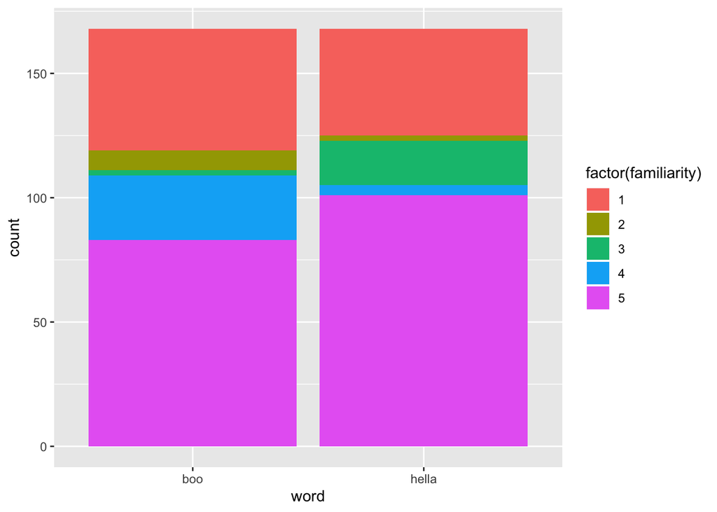

```r
hiphop_clean %>%
  filter(word %in% c("hella", "boo")) %>%
  ggplot(aes(x = word, fill = factor(familiarity))) + geom_bar()
```

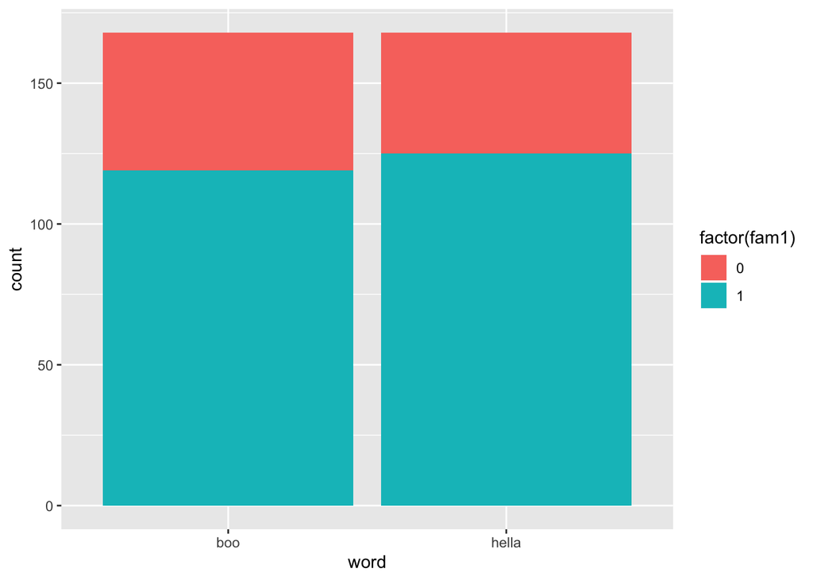

```r
hiphop_clean %>%
  filter(word %in% c("hella", "boo")) %>%
  ggplot(aes(x = word, fill = factor(fam1))) + geom_bar()
```

### QUESTION 3

Aubrey’s true life dream is to collaborate with his fellow Canadian musician Justin Bieber. Luckily, he knows that Bieber himself was one of the subjects in this study! You know that Bieber is a white male, aged 17-23 at the time of the study, from a relatively small town (10,000-60,000 people) in Ontario.

Determine which subject is secretly Bieber, and justify your answer.

Hint: Refer again to the dataset description. There is another clue about Bieber’s identity.

```r
hiphop_clean %>%
  filter(sex == 'Male') %>%
  filter(clean_ethnic == 'white') %>%
  filter(age >= 17 & age <= 23) %>%
  filter(city >= 10000 & city <= 60000) %>%
  filter(bieber >= 5.0) %>%
  filter(jayz == 5) %>%
  arrange(desc(bieber))
```

```
## # A tibble: 64 x 39
##    word  subj  sex     age ethnic  city county  intl vocal classical  folk  rock
##    <fct> <fct> <fct> <dbl> <fct>  <dbl>  <dbl> <dbl> <dbl>     <dbl> <dbl> <dbl>
##  1 [to … p17   Male     18 white  56377 331582     0     1         0     0     1
##  2 5-0   p17   Male     18 white  56377 331582     0     1         0     0     1
##  3 A-to… p17   Male     18 white  56377 331582     0     1         0     0     1
##  4 ashy  p17   Male     18 white  56377 331582     0     1         0     0     1
##  5 ay y… p17   Male     18 white  56377 331582     0     1         0     0     1
##  6 ball… p17   Male     18 white  56377 331582     0     1         0     0     1
##  7 beezy p17   Male     18 white  56377 331582     0     1         0     0     1
##  8 bones p17   Male     18 white  56377 331582     0     1         0     0     1
##  9 boo   p17   Male     18 white  56377 331582     0     1         0     0     1
## 10 boug… p17   Male     18 white  56377 331582     0     1         0     0     1
## # … with 54 more rows, and 27 more variables: country <dbl>, pop <dbl>,
## #   alternative <dbl>, hiphop <dbl>, unclassifiable <dbl>, countyBlack <dbl>,
## #   jayz <dbl>, barkley <dbl>, boondocks <dbl>, monique <dbl>, bieber <dbl>,
## #   asianMove <dbl>, blackMove <dbl>, hispanicMove <dbl>, nativeMove <dbl>,
## #   SAAMEMove <dbl>, whiteMove <dbl>, blackWeekly <dbl>, jayz1 <dbl>,
## #   boondocks1 <dbl>, familiarity <dbl>, trial <dbl>, fam1 <dbl>,
## #   popularityScore <dbl>, numPreferredArtists <dbl>, numOverallArtists <dbl>,
## #   clean_ethnic <fct>
```

```r
#it's person 17!!!
```

My thought process here after filtering the data to the listed description was filtering it for subjects who rated higher on beiber column as Justin Bieber himself should be expected to know all his songs. I didnt set it to 6 because (1) the level 6 wasn’t remaning after filtering assuming that Justin Bieber didn’t want to reveal his identity by showing that he knows the max amount of songs. I then filtered jayz to be 5 as being in the superstar community, Justin Bieber would probably know something like who jayz is married to. I was then left with 64 people (64 observations of the same person) being subject 17.

### QUESTION 4

Use the dataset to suggest a track listing (11 song titles) for Aubrey’s next album with the Biebs. Explain your thought process and corresponding code.

```r
hiphop_clean %>%
  filter(bieber == 6) %>%
  filter(hiphop >= 8) %>%
  filter(familiarity == 5) %>%
  group_by(word) %>%
  #select(word, bieber, hiphop, fam1, familiarity) %>%
  distinct(hiphop_clean,word, .keep_all = TRUE)
```

```
## # A tibble: 26 x 39
## # Groups:   word [26]
##    word  subj  sex     age ethnic   city county  intl vocal classical  folk
##    <fct> <fct> <fct> <dbl> <fct>   <dbl>  <dbl> <dbl> <dbl>     <dbl> <dbl>
##  1 [to … p46   Fema…    20 white  281262 5.06e5     0     0         0     0
##  2 5-0   p20   Fema…    18 afric… 385542 1.16e6     0     0         0     0
##  3 A-to… p20   Fema…    18 afric… 385542 1.16e6     0     0         0     0
##  4 ashy  p20   Fema…    18 afric… 385542 1.16e6     0     0         0     0
##  5 ball… p46   Fema…    20 white  281262 5.06e5     0     0         0     0
##  6 boo   p20   Fema…    18 afric… 385542 1.16e6     0     0         0     0
##  7 boug… p20   Fema…    18 afric… 385542 1.16e6     0     0         0     0
##  8 ched… p20   Fema…    18 afric… 385542 1.16e6     0     0         0     0
##  9 chee… p20   Fema…    18 afric… 385542 1.16e6     0     0         0     0
## 10 CP t… p46   Fema…    20 white  281262 5.06e5     0     0         0     0
## # … with 16 more rows, and 28 more variables: rock <dbl>, country <dbl>,
## #   pop <dbl>, alternative <dbl>, hiphop <dbl>, unclassifiable <dbl>,
## #   countyBlack <dbl>, jayz <dbl>, barkley <dbl>, boondocks <dbl>,
## #   monique <dbl>, bieber <dbl>, asianMove <dbl>, blackMove <dbl>,
## #   hispanicMove <dbl>, nativeMove <dbl>, SAAMEMove <dbl>, whiteMove <dbl>,
## #   blackWeekly <dbl>, jayz1 <dbl>, boondocks1 <dbl>, familiarity <dbl>,
## #   trial <dbl>, fam1 <dbl>, popularityScore <dbl>, numPreferredArtists <dbl>,
## #   numOverallArtists <dbl>, clean_ethnic <fct>
```

My thought process with this question was to filter the data by the ‘bieber’ condition at the max value as a true Justin Beiber (one who knows a lot of songs by him), would be the most inclined to hear a song featuring him. I then filtered the hip hop category to be greater than or equal to 8 as that was the max rating of hip hop liking for the previously filtered justin bieber inclined subjects. I then filtered familiarity to be equal to 5 as that was the highest level option for rating hip hop songs - we want people who (1) like hip hop and (2) recognize most of the words listed as they will resonate with them more when listed in the song titles. After that, I grouped the data by word then cleaned it to only show the distinct words. I was left with 26 unique words in which I randomly arranged to make song titles.

Song titles: Boo, Ballin’ & Boogie Facheezie Guap Straight Cash Road Dog, Toe Up Ay Yo Trip Heezy Twurk, Trill, Twurk Feel Me Cheese What it Do Road Dog Finna Make it Rain Hella Good Hair Chedda Cheese